# Rottnest comparison

We can also easily calculate alpha diversity across these tools, as alpha diversity is the number of species. We treat classifiers/Types as sites.

```r
spec_summarised <- twelve_exclusions_split |>
  group_by(Type, Query, Database, after) |>
  mutate(Database = case_when ( Database == 'fifty' ~ '50%',
                               Database == 'seventy' ~ '70%',
                               Database == 'thirty' ~ '30%',
                               TRUE ~ Database)) |>
  filter(!is.na(species)) |>
  summarise(`Alpha diversity index` = length(unique(species)))
```

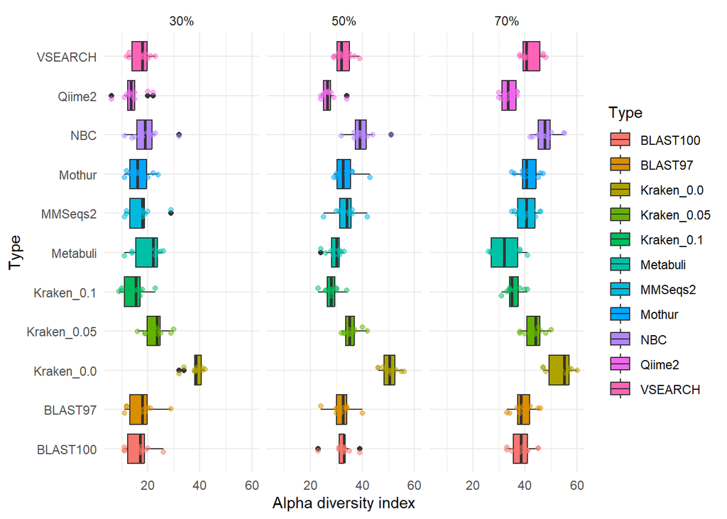

```r
spec_summarised |>
  ggplot(aes(x = Type, y = `Alpha diversity index`, fill=Type, group = Type )) +
  geom_boxplot() +
  geom_point(aes(color=Type),
           position = position_jitterdodge(jitter.width = 0.2),
           alpha=0.5,
           show.legend = FALSE) +
  facet_wrap(~Database) + coord_flip() + theme_minimal()
```

Let’s also do not all of the classifiers

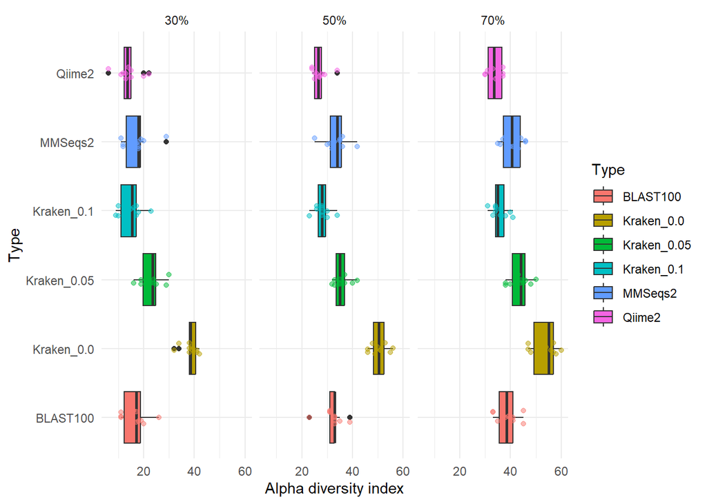

```r
spec_summarised |>
  filter(Type %in% c('BLAST100', 'Kraken_0.0', 'Kraken_0.05', 'Kraken_0.1','MMSeqs2', 'Qiime2')) |>
  ggplot(aes(x = Type, y = `Alpha diversity index`, fill=Type, group = Type )) +
  geom_boxplot() +
  geom_point(aes(color=Type),
           position = position_jitterdodge(jitter.width = 0.2),
           alpha=0.5,
           show.legend = FALSE) +
  facet_wrap(~Database) + coord_flip() + theme_minimal()
```

```r
a <- spec_summarised |>
  filter(Type %in% c('BLAST100', 'BLAST97', 'Kraken_0.0','Kraken_0.05', 'Kraken_0.1','MMSeqs2', 'Qiime2')) |>
  group_by(Database) |>
  arrange(Database) |>
  group_map(~aov(`Alpha diversity index` ~ Type, data=.))

names(a) <- spec_summarised |> arrange(Database) |> pull(Database) |> unique() # I don't like this :(
a
```

```
## $`30%`
## Call:
##    aov(formula = `Alpha diversity index` ~ Type, data = .)
##
## Terms:
##                     Type Residuals
## Sum of Squares  4247.086  1315.200
## Deg. of Freedom        6        63
##
## Residual standard error: 4.569047
## Estimated effects may be unbalanced
##
## $`50%`
## Call:
##    aov(formula = `Alpha diversity index` ~ Type, data = .)
##
## Terms:
##                     Type Residuals
## Sum of Squares  3679.743   836.200
## Deg. of Freedom        6        63
##
## Residual standard error: 3.643215
## Estimated effects may be unbalanced
##
## $`70%`
## Call:
##    aov(formula = `Alpha diversity index` ~ Type, data = .)
##
## Terms:
##                     Type Residuals
## Sum of Squares  2587.771   999.600
## Deg. of Freedom        6        63
##
## Residual standard error: 3.983298
## Estimated effects may be unbalanced
```

```r
library(agricolae)
groupslist <- list()

for(key in names(a)) {
  print(key)
  groupslist[[key]] <- HSD.test(a[[key]], 'Type')$groups|>
    as_tibble(rownames = 'Type') |>
    select(-`Alpha diversity index`)
}
```

```
## [1] "30%"
## [1] "50%"
## [1] "70%"
```

```r
groups_df <- bind_rows(groupslist, .id='Database')
```

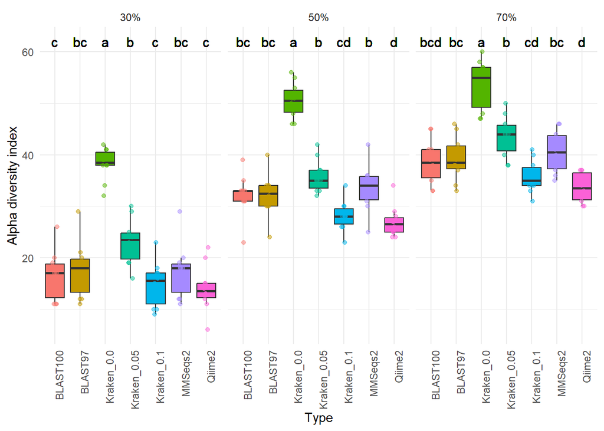

```r
spec_summarised |>
  filter(Type %in% c('BLAST100', 'BLAST97', 'Kraken_0.0', 'Kraken_0.05', 'Kraken_0.1','MMSeqs2', 'Qiime2')) |>
  left_join(groups_df, by = c('Database', 'Type')) |>
  ggplot(aes(x = Type, y = `Alpha diversity index`, fill=Type, group = Type )) +
  geom_boxplot(outlier.shape=NA) +
  geom_point(aes(color=Type),
           position = position_jitterdodge(jitter.width = 0.2),
           alpha=0.5,
           show.legend = FALSE) +
  facet_wrap(~Database) +
  geom_text(aes(x = Type, y = max(`Alpha diversity index`) + 2, label = groups),
            #col = 'black',
            size = 4) +
  #coord_flip() +
  theme_minimal() +
  theme(axis.text.x = element_text( angle = 90, hjust = 1)) +
  guides(fill="none")
```

## 16S exclusion databases

```r
sixteen_exclusions <- data |> filter(str_starts(Subject, '16S_v04_final.fasta_Taxonomies.')) |>
  filter(Query == 'make_12s_16s_simulated_reads_8-Rottnest_runEDNAFLOW_16S_RESULTS_dada2_asv.fa')
table(sixteen_exclusions$Subject)
```

```
##
##    16S_v04_final.fasta_Taxonomies.CountedFams.txt_fifty_subset_1.fasta
##                                                                    873
##   16S_v04_final.fasta_Taxonomies.CountedFams.txt_fifty_subset_10.fasta
##                                                                    861
##    16S_v04_final.fasta_Taxonomies.CountedFams.txt_fifty_subset_2.fasta
##                                                                    951
##    16S_v04_final.fasta_Taxonomies.CountedFams.txt_fifty_subset_3.fasta
##                                                                    870
##    16S_v04_final.fasta_Taxonomies.CountedFams.txt_fifty_subset_4.fasta
##                                                                    871
##    16S_v04_final.fasta_Taxonomies.CountedFams.txt_fifty_subset_5.fasta
##                                                                    880
##    16S_v04_final.fasta_Taxonomies.CountedFams.txt_fifty_subset_6.fasta
##                                                                    904
##    16S_v04_final.fasta_Taxonomies.CountedFams.txt_fifty_subset_7.fasta
##                                                                    933
##    16S_v04_final.fasta_Taxonomies.CountedFams.txt_fifty_subset_8.fasta
##                                                                    843
##    16S_v04_final.fasta_Taxonomies.CountedFams.txt_fifty_subset_9.fasta
##                                                                    867
##  16S_v04_final.fasta_Taxonomies.CountedFams.txt_seventy_subset_1.fasta
##                                                                    979
## 16S_v04_final.fasta_Taxonomies.CountedFams.txt_seventy_subset_10.fasta
##                                                                    992
##  16S_v04_final.fasta_Taxonomies.CountedFams.txt_seventy_subset_2.fasta
##                                                                    955
##  16S_v04_final.fasta_Taxonomies.CountedFams.txt_seventy_subset_3.fasta
##                                                                    963
##  16S_v04_final.fasta_Taxonomies.CountedFams.txt_seventy_subset_4.fasta
##                                                                    906
##  16S_v04_final.fasta_Taxonomies.CountedFams.txt_seventy_subset_5.fasta
##                                                                   1014
##  16S_v04_final.fasta_Taxonomies.CountedFams.txt_seventy_subset_6.fasta
##                                                                    936
##  16S_v04_final.fasta_Taxonomies.CountedFams.txt_seventy_subset_7.fasta
##                                                                    960
##  16S_v04_final.fasta_Taxonomies.CountedFams.txt_seventy_subset_8.fasta
##                                                                    991
##  16S_v04_final.fasta_Taxonomies.CountedFams.txt_seventy_subset_9.fasta
##                                                                    993
##   16S_v04_final.fasta_Taxonomies.CountedFams.txt_thirty_subset_1.fasta
##                                                                    796
##  16S_v04_final.fasta_Taxonomies.CountedFams.txt_thirty_subset_10.fasta
##                                                                    824
##   16S_v04_final.fasta_Taxonomies.CountedFams.txt_thirty_subset_2.fasta
##                                                                    814
##   16S_v04_final.fasta_Taxonomies.CountedFams.txt_thirty_subset_3.fasta
##                                                                    790
##   16S_v04_final.fasta_Taxonomies.CountedFams.txt_thirty_subset_4.fasta
##                                                                    869
##   16S_v04_final.fasta_Taxonomies.CountedFams.txt_thirty_subset_5.fasta
##                                                                    806
##   16S_v04_final.fasta_Taxonomies.CountedFams.txt_thirty_subset_6.fasta
##                                                                    745
##   16S_v04_final.fasta_Taxonomies.CountedFams.txt_thirty_subset_7.fasta
##                                                                    856
##   16S_v04_final.fasta_Taxonomies.CountedFams.txt_thirty_subset_8.fasta
##                                                                    785
##   16S_v04_final.fasta_Taxonomies.CountedFams.txt_thirty_subset_9.fasta
##                                                                    805
```

```r
sixteen_exclusions_split <- sixteen_exclusions |> separate(Subject, into = c('before', 'hit'), sep='.txt_') |>
  # get rid of leftover non-subsetted databases
  filter(!is.na(hit)) |>
  separate(hit, into=c('Database', 'after'), sep='_subset')
```

```r
sixteen_exclusions_split_averaged <- sixteen_exclusions_split |> left_join(sixteenS_truth, by = c('OTU' = 'True_OTU')) |>
  separate(True_species, into = c('True_Genus', 'True_Epiteth'), remove = FALSE)|>
  mutate(species = na_if(species, 'dropped')) |>
  mutate(genus = na_if(genus, 'dropped')) |>

  mutate(CorrectSpecies = case_when(!is.na(species) & True_species == species ~ 'Correct species',
                              !is.na(species) & True_species != species ~ 'Incorrect species',
                              !is.na(genus) & !is.na(True_Genus) & True_Genus == genus ~ 'Correct genus',
                              !is.na(genus) & !is.na(True_Genus) & True_Genus != genus ~ 'Incorrect genus',
                              !is.na(family) & True_family == family ~ 'Correct family',
                              !is.na(family) & True_family != family ~ 'Incorrect family',
                              TRUE ~ NA)) |>
  group_by(Type, Database, after) |>
  summarise(TP = sum(str_detect(CorrectSpecies, pattern='Correct species'), na.rm=TRUE),
            FP = sum(str_detect(CorrectSpecies, pattern = 'Incorrect species'), na.rm=TRUE),
            TN = sum(str_detect(replace_na(CorrectSpecies,'NA'), pattern='NA') & is.na(True_species), na.rm=TRUE),
            FN = sum(is.na(species) & !is.na(True_species))) |>
  mutate(sums = TP + FP + TN + FN) |>
  mutate(missing = 102 - sums) |>
  mutate(FN = FN + missing) |>
  mutate(sums = TP + FP + TN + FN) |>
  select(-c(missing, sums)) |>
  group_by(Type, Database) |>
  summarise(mean_TP = mean(TP),
            mean_FP = mean(FP),
            mean_TN = mean(TN),
            mean_FN = mean(FN)) |>
  rowwise() |>
  mutate(recall = recall(mean_TP, mean_FN),
         precision = precision(mean_TP, mean_FP),
         f1 = f1(precision, recall),
         f0.5 = f0.5(precision, recall),
         accuracy = accuracy(mean_TP, mean_FP, mean_FN, mean_TN))
sixteen_exclusions_split_averaged <- sixteen_exclusions_split_averaged |>
  mutate(Database = case_when ( Database == 'fifty' ~ '50%',
                               Database == 'seventy' ~ '70%',
                               Database == 'thirty' ~ '30%',
                               TRUE ~ Database))
```

```r
f1_pl <- sixteen_exclusions_split_averaged |>
  ggplot(aes(x = Type, y = f1, group = Database, color = Database, fill = Database)) +
  geom_point() +
  geom_line() +
  theme_minimal()
```

```r
f0.5_pl <- sixteen_exclusions_split_averaged |>
  ggplot(aes(x = Type, y = f0.5, group = Database, color = Database, fill = Database)) +
  geom_point() +
  geom_line() +
  theme_minimal()
```

```r
precision_pl <- sixteen_exclusions_split_averaged |>
  ggplot(aes(x = Type, y = precision, group = Database, color = Database, fill = Database)) +
  geom_point() +
  geom_line() +
  theme_minimal()
```

```r
recall_pl <- sixteen_exclusions_split_averaged |>
  ggplot(aes(x = Type, y = recall, group = Database, color = Database, fill = Database)) +
  geom_point() +
  geom_line() +
  theme_minimal()
```

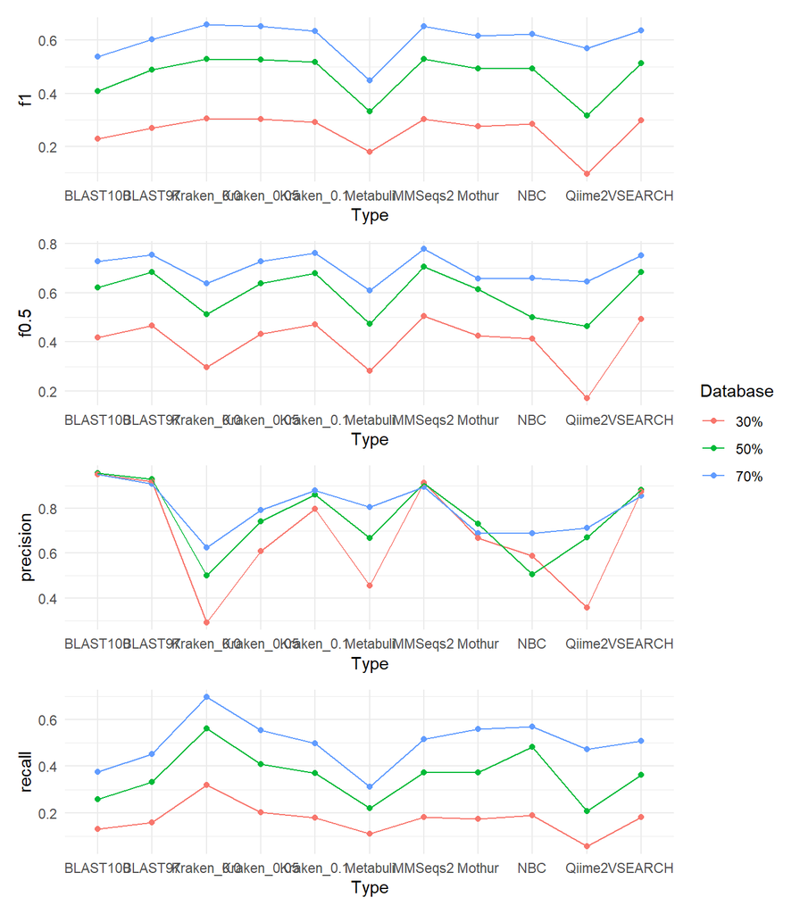

```r
(f1_pl / f0.5_pl / precision_pl / recall_pl) +  plot_layout(guides = 'collect')
```

Lets zero in on the precision and make boxplots with jitter dots

```r
un_summarised_sixteen <- sixteen_exclusions_split |> left_join(sixteenS_truth, by = c('OTU' = 'True_OTU')) |>
  separate(True_species, into = c('True_Genus', 'True_Epiteth'), remove = FALSE)|>
  mutate(species = na_if(species, 'dropped')) |>
  mutate(genus = na_if(genus, 'dropped')) |>

  mutate(CorrectSpecies = case_when(!is.na(species) & True_species == species ~ 'Correct species',
                              !is.na(species) & True_species != species ~ 'Incorrect species',
                              !is.na(genus) & !is.na(True_Genus) & True_Genus == genus ~ 'Correct genus',
                              !is.na(genus) & !is.na(True_Genus) & True_Genus != genus ~ 'Incorrect genus',
                              !is.na(family) & True_family == family ~ 'Correct family',
                              !is.na(family) & True_family != family ~ 'Incorrect family',
                              TRUE ~ NA)) |>
  group_by(Type, Database, after) |>
  summarise(TP = sum(str_detect(CorrectSpecies, pattern='Correct species'), na.rm=TRUE),
            FP = sum(str_detect(CorrectSpecies, pattern = 'Incorrect species'), na.rm=TRUE),
            TN = sum(str_detect(replace_na(CorrectSpecies,'NA'), pattern='NA') & is.na(True_species), na.rm=TRUE),
            FN = sum(is.na(species) & !is.na(True_species))) |>
  mutate(sums = TP + FP + TN + FN) |>
  mutate(missing = 112 - sums) |>
  mutate(FN = FN + missing) |>
  mutate(sums = TP + FP + TN + FN) |>
  select(-c(missing, sums)) |>
  rowwise() |>
  mutate(recall = recall(TP, FN),
         precision = precision(TP, FP),
         f1 = f1(precision, recall),
         f0.5 = f0.5(precision, recall),
         accuracy = accuracy(TP, FP, FN, TN)) |>
  mutate(Database = case_when ( Database == 'fifty' ~ '50%',
                               Database == 'seventy' ~ '70%',
                               Database == 'thirty' ~ '30%',
                               TRUE ~ Database))
```

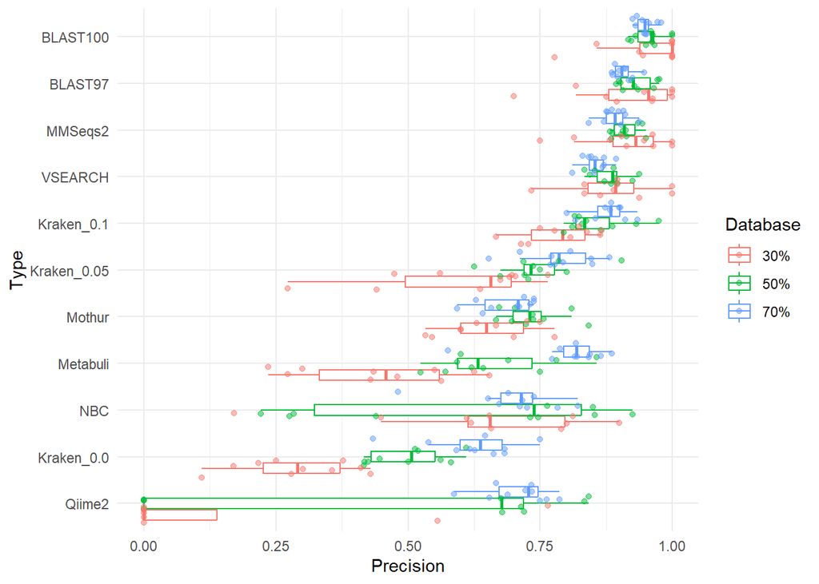

```r
un_summarised_sixteen |> group_by(Type, Database) |> mutate(best = max(mean(precision))) |>
  ggplot(aes(x = fct_reorder(Type, best), group = interaction(Type, Database),  color=Database, y = precision)) +
  geom_boxplot(outlier.shape = NA) +
  coord_flip() +
  theme_minimal() +
  xlab('Type') +
  ylab('Precision') +
  geom_point(position = position_jitterdodge(), alpha=0.5)
```

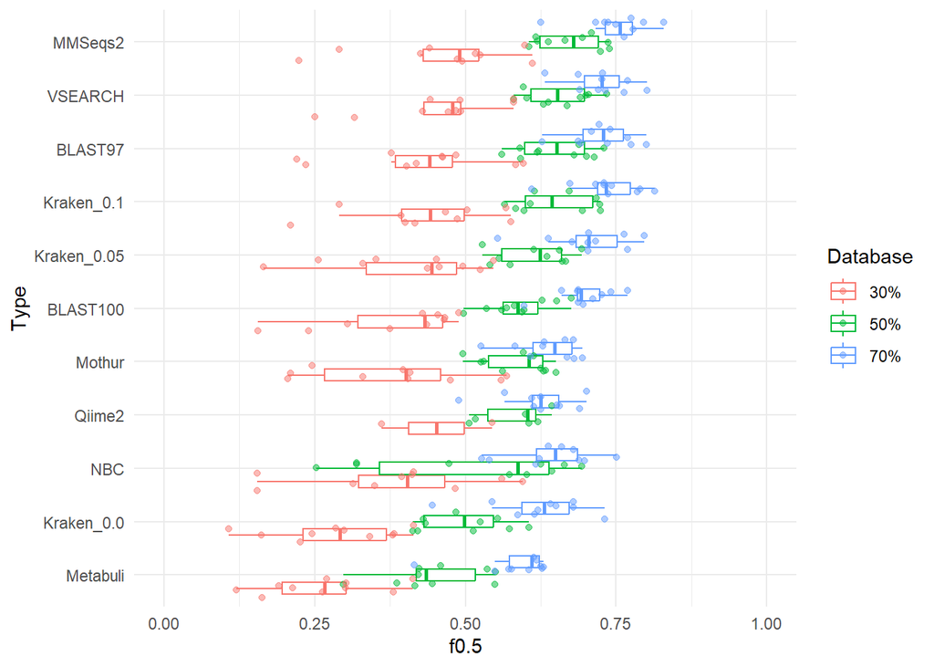

```r
un_summarised_sixteen  |> group_by(Type, Database) |> mutate(best = max(mean(f0.5, na.rm=TRUE))) |>
  ggplot(aes(x = fct_reorder(Type, best), group = interaction(Type, Database), color=Database, y = f0.5)) +
  geom_boxplot(outlier.shape = NA) +
  coord_flip() +
  theme_minimal() +
  xlab('Type') +
  ylab('f0.5') +
  ylim(c(0, 1)) +
  geom_point(position = position_jitterdodge(), alpha=0.5)
```

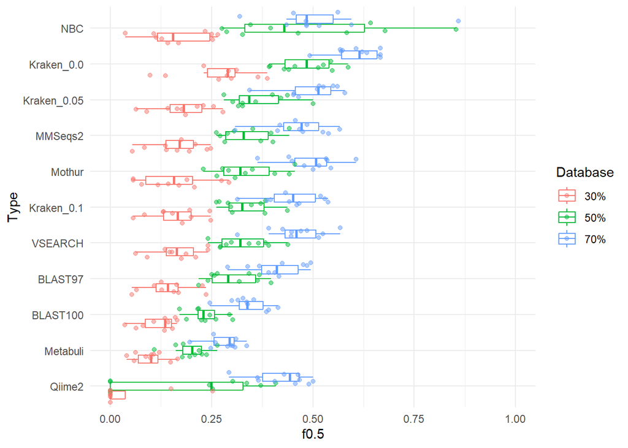

```r
un_summarised_sixteen  |> group_by(Type, Database) |> mutate(best = max(mean(recall))) |>
  ggplot(aes(x = fct_reorder(Type, best), group = interaction(Type, Database), color=Database, y = recall)) +
  geom_boxplot(outlier.shape = NA) +
  coord_flip() +
  theme_minimal() +
  xlab('Type') +
  ylab('f0.5') +
  ylim(c(0, 1)) +
  geom_point(position = position_jitterdodge(), alpha=0.5)
```

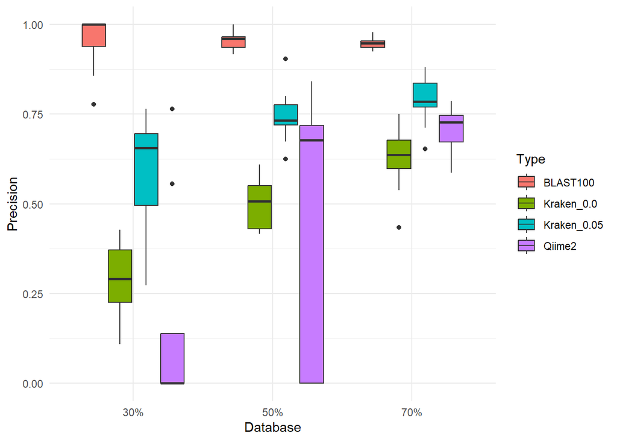

```r
un_summarised_sixteen  |>
  filter(Type %in% c('BLAST100', 'Kraken_0.0',  'Kraken_0.05', 'Qiime2')) |>
  ggplot(aes(x=Database, y = precision, fill=Type)) + #fill=factor(Database, levels=c('30%','50%','70%')))) +
  geom_boxplot() +
  labs(fill='Type') +
  ylab('Precision') +
  theme_minimal()
```

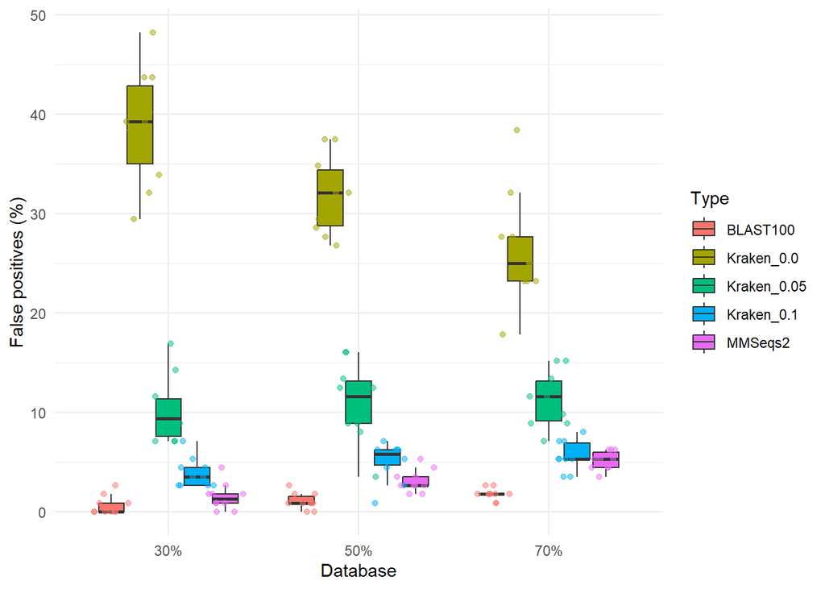

```r
false_positives <- un_summarised_sixteen  |>
  filter(Type %in% c('BLAST100', 'Kraken_0.0',  'Kraken_0.05', 'Kraken_0.1', 'MMSeqs2')) |>
  ggplot(aes(x=Database, y = FP/112*100, fill=Type)) + #fill=factor(Database, levels=c('30%','50%','70%')))) +
  geom_boxplot(outlier.shape=NA) +
  labs(fill='Type') +
  ylab('False positives (%)') +
  geom_point(aes(color=Type),
             position = position_jitterdodge(jitter.width = 0.2),
             alpha=0.5,
             show.legend = FALSE)+
  theme_minimal()
false_positives
```

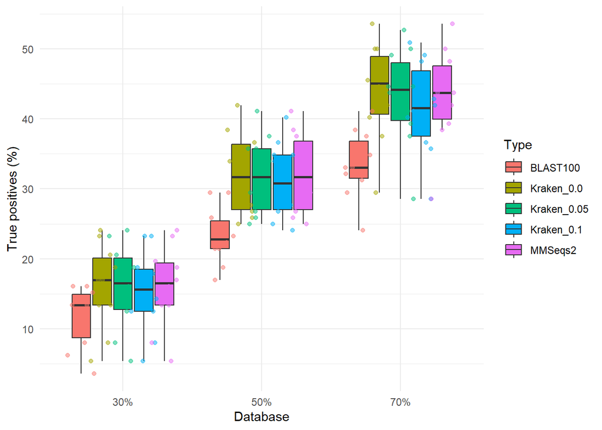

```r
true_positives <- un_summarised_sixteen  |>
  filter(Type %in% c('BLAST100', 'Kraken_0.0',  'Kraken_0.05', 'Kraken_0.1', 'MMSeqs2')) |>
  ggplot(aes(x=Database, y = TP/112*100, fill=Type)) + #fill=factor(Database, levels=c('30%','50%','70%')))) +
  geom_boxplot(outlier.shape=NA) +
  labs(fill='Type') +
  ylab('True positives (%)') +
  geom_point(aes(color=Type),
           position = position_jitterdodge(jitter.width = 0.2),
           alpha=0.5,
           show.legend = FALSE)+
  theme_minimal()
true_positives
```

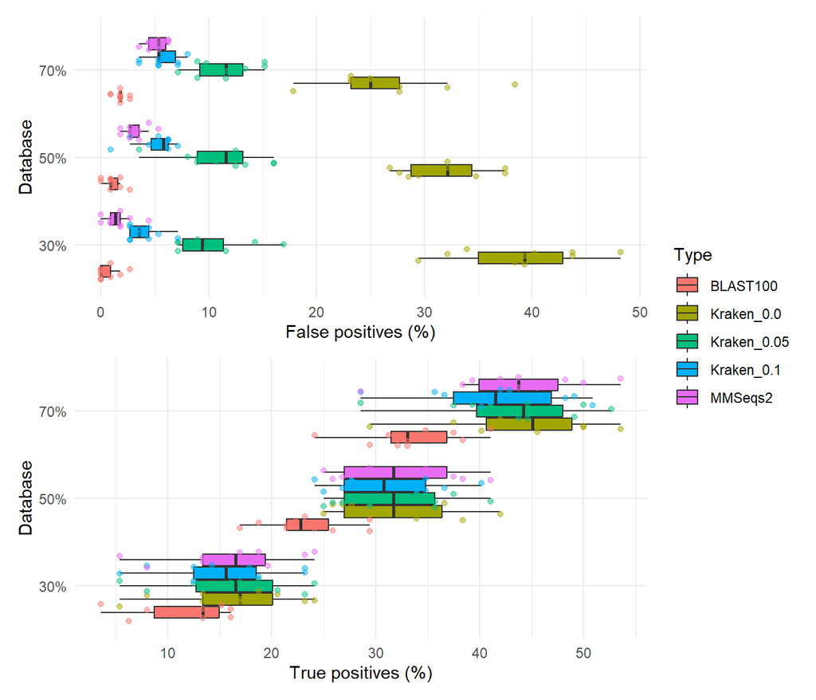

```r
false_positives/ true_positives + plot_layout(guides = 'collect') & coord_flip()
```

We can also easily calculate alpha diversity across these tools, as alpha diversity is the number of species. We treat classifiers/Types as sites.

```r
spec_summarised <- sixteen_exclusions_split |>
  group_by(Type, Query, Database, after) |>
  mutate(Database = case_when ( Database == 'fifty' ~ '50%',
                               Database == 'seventy' ~ '70%',
                               Database == 'thirty' ~ '30%',
                               TRUE ~ Database)) |>
  filter(!is.na(species)) |>
  summarise(`Alpha diversity index` = length(unique(species)))
```

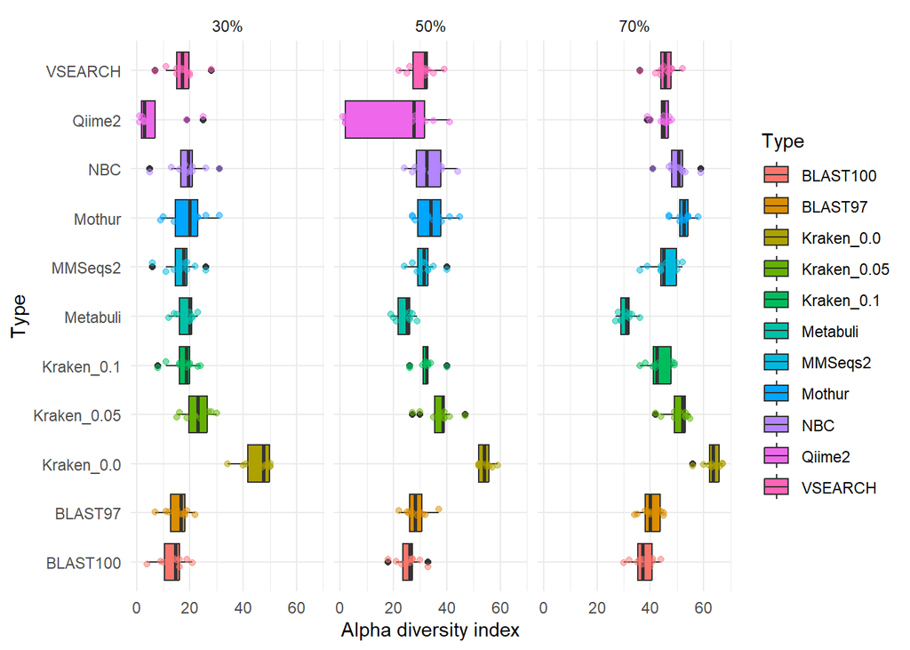

```r
spec_summarised |>
  ggplot(aes(x = Type, y = `Alpha diversity index`, fill=Type, group = Type )) +
  geom_boxplot() +
  geom_point(aes(color=Type),
           position = position_jitterdodge(jitter.width = 0.2),
           alpha=0.5,
           show.legend = FALSE) +
  facet_wrap(~Database) + coord_flip() + theme_minimal()
```

Let’s also do not all of the classifiers

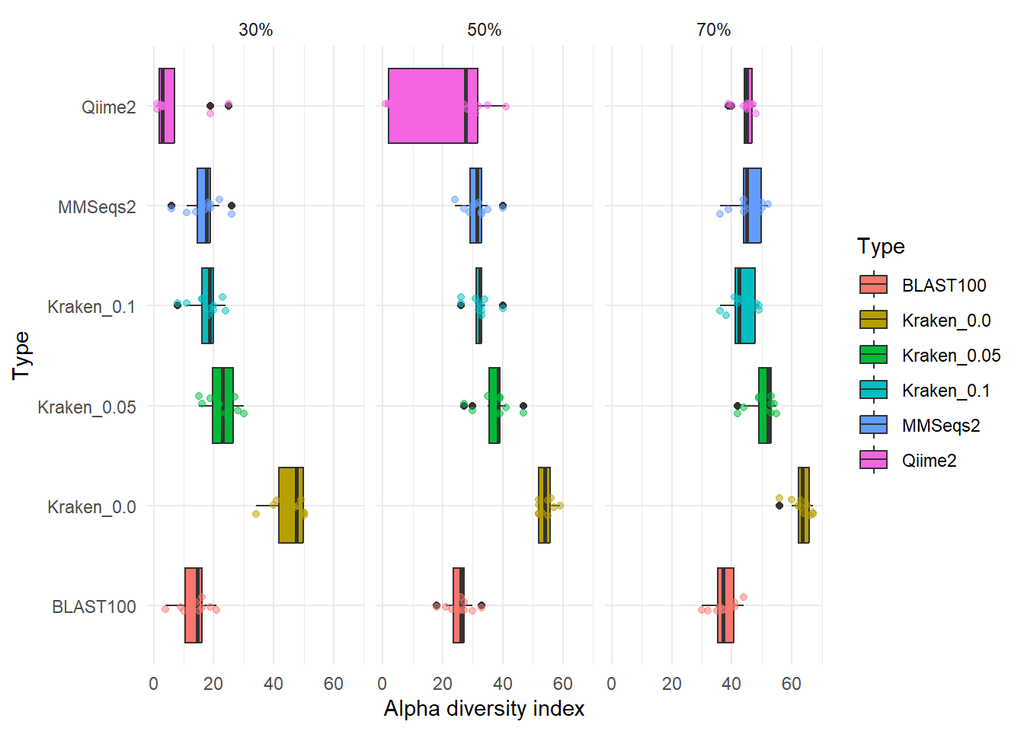

```r
spec_summarised |>
  filter(Type %in% c('BLAST100', 'Kraken_0.0', 'Kraken_0.05',  'Kraken_0.1','MMSeqs2', 'Qiime2')) |>
  ggplot(aes(x = Type, y = `Alpha diversity index`, fill=Type, group = Type )) +
  geom_boxplot() +
  geom_point(aes(color=Type),
           position = position_jitterdodge(jitter.width = 0.2),
           alpha=0.5,
           show.legend = FALSE) +
  facet_wrap(~Database) + coord_flip() + theme_minimal()
```

```r
a <- spec_summarised |>
  filter(Type %in% c('BLAST100', 'BLAST97', 'Kraken_0.0',  'Kraken_0.05', 'Kraken_0.1','MMSeqs2', 'Qiime2')) |>
  group_by(Database) |>
  arrange(Database) |>
  group_map(~aov(`Alpha diversity index` ~ Type, data=.))

names(a) <- spec_summarised |> arrange(Database) |> pull(Database) |> unique() # I don't like this :(
a
```

```
## $`30%`
## Call:
##    aov(formula = `Alpha diversity index` ~ Type, data = .)
##
## Terms:
##                     Type Residuals
## Sum of Squares  8580.307  2011.575
## Deg. of Freedom        6        61
##
## Residual standard error: 5.742529
## Estimated effects may be unbalanced
##
## $`50%`
## Call:
##    aov(formula = `Alpha diversity index` ~ Type, data = .)
##
## Terms:
##                     Type Residuals
## Sum of Squares  7157.943  3359.900
## Deg. of Freedom        6        63
##
## Residual standard error: 7.302859
## Estimated effects may be unbalanced
##
## $`70%`
## Call:
##    aov(formula = `Alpha diversity index` ~ Type, data = .)
##
## Terms:
##                     Type Residuals
## Sum of Squares  4334.886  1085.700
## Deg. of Freedom        6        63
##
## Residual standard error: 4.151305
## Estimated effects may be unbalanced
```

```r
library(agricolae)
groupslist <- list()

for(key in names(a)) {
  print(key)
  groupslist[[key]] <- HSD.test(a[[key]], 'Type')$groups|>
    as_tibble(rownames = 'Type') |>
    select(-`Alpha diversity index`)
}
```

```
## [1] "30%"
## [1] "50%"
## [1] "70%"
```

```r
groups_df <- bind_rows(groupslist, .id='Database')
```

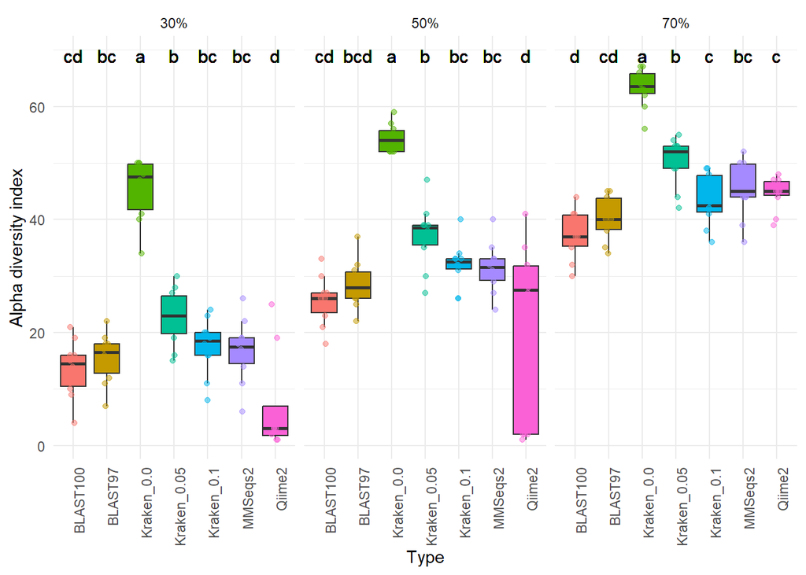

```r
spec_summarised |>
  filter(Type %in% c('BLAST100', 'BLAST97', 'Kraken_0.0', 'Kraken_0.05',  'Kraken_0.1','MMSeqs2', 'Qiime2')) |>
  left_join(groups_df, by = c('Database', 'Type')) |>
  ggplot(aes(x = Type, y = `Alpha diversity index`, fill=Type, group = Type )) +
  geom_boxplot(outlier.shape=NA) +
  geom_point(aes(color=Type),
           position = position_jitterdodge(jitter.width = 0.2),
           alpha=0.5,
           show.legend = FALSE) +
  facet_wrap(~Database) +
  geom_text(aes(x = Type, y = max(`Alpha diversity index`) + 2, label = groups),
            #col = 'black',
            size = 4) +
  #coord_flip() +
  theme_minimal() +
  theme(axis.text.x = element_text( angle = 90, hjust = 1)) +
  guides(fill="none")
```